# Exam_One_A - Raven T. Sutton

# Terminology

1. What is the difference between a *population* and a *sample*?

Answer: A population is the entire pool from which a statistical sample is drawn and a sample is a selection of the entire population to act as a representative in order to keep from having to test all applicable test subjects. The main difference is that a sample is used to represent a total population.

good

2. What is the difference between a *statistic* and a *parameter*. Give an example of a *statistic*.

Answer:A statistic is any quantity computed from values in a sample that is used for a statistical purpose and a parameter is any quantity computed from values in a sample that is used for a statistical purpose. An example of a statistics would be 56% of college students are female.

You wrote the same thing for both statistic and parameter. A parameter is a quantity that describes the population.

3. In a data set, what is the difference between an *observation* and a *variable*?

Answer: An observation is a value of something of interest youre measuring or counting during a study or experiment and a variable is any characteristics, number, or quantity that can be measured or counted. The variables in an experiment is what is being observed.

An observation is one element in a data set: a person, a tree, etc. (6/9)

# Exploratory Data Analysis

```r
library(resampledata)
BeerData<-Alelager
```

```r
#BeerData<-read.csv("https://sites.google.com/site/chiharahesterberg/data2/Alelager.csv")
#head(BeerData)
```

1. Create side-by-side box plots of the alcohol content, grouped by beer type. Comment on the information the box plots convey.

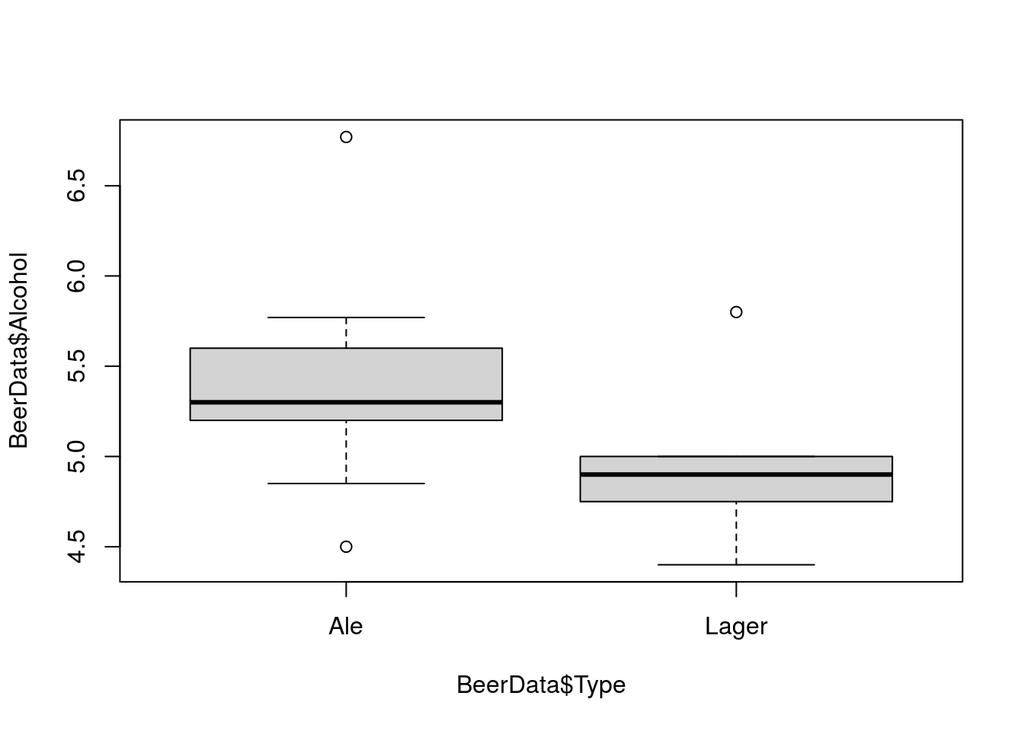

```r
boxplot(BeerData$Alcohol~BeerData$Type)
```

Commentary: The box plots tell us that lagers generally have a lower alcohol content that Ales.

good

2. Create a histogram of the calorie content of all beers in the data set. Describe the distribution.

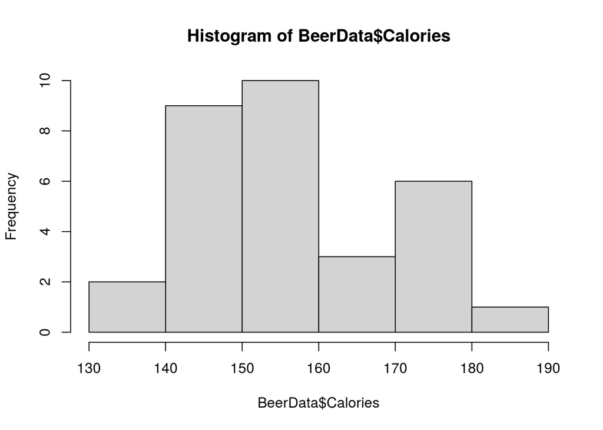

```r
hist(BeerData$Calories)
```

I think the skew is right. (6/6) (12/15)

3. Sampling Distribution
- Simulate the sampling distribution of the mean of the number of calories, for samples of size 3.

```r
N=10^4
Xbar <- numeric(N)
for (i in 1:N)
  {samp <- sample(BeerData$Calories, size=3,replace=F)
  Xbar[i] <- mean(samp)}
MX <- mean(Xbar)
MX
```

```
## [1] 158.5771
```

- Create a histogram and describe the simulated sampling distribution.

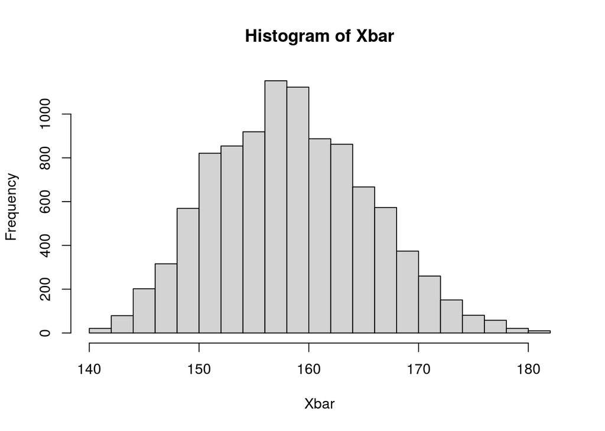

```r
hist(Xbar)
```

- Use the simulation to find the probability that the average calorie content of 3 beers is less than 150 calories.

```r
min(BeerData$Calories)
```

```
## [1] 138
```

```r
max(BeerData$Calories)
```

```
## [1] 187
```

```r
length(BeerData$Calories)
```

```
## [1] 31
```

```r
prob150 <- mean(MX<150)
probcal150<-pbinom(150,187,MX)-pbinom(138,187,MX)
```

- Use the simulation to find the probability that the average calorie content of 3 beers is more than 160 calories.

```r
probcal150<-pbinom(187,187,MX)-pbinom(160,187,MX)
```

Use mean(Xbar>160) to find probability. (5/7) (17/22)

4. The following code generates two ecdfs, one for calories of ales, one for calories of lagers.

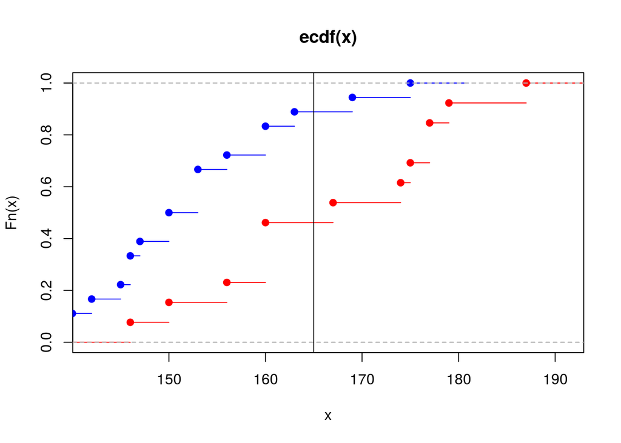

```r
Ales <- subset(BeerData, select=Calories, subset=Type=="Ale", drop=T)
Lagers <- subset(BeerData, select=Calories, subset=Type=="Lager", drop=T)
#plot.new()
plot.ecdf(Ales, col="red")
plot.ecdf(Lagers, col="blue", add=TRUE)
abline(v=165)
```

No, about 50% and 90%. (0/3) (17/25)

# Permutation test

Conduct a permutation test to determine whether there is a difference in the mean calorie content between ales and lagers. Your test should start with a statement of the formal hypotheses and finish with a conclusion.

Put each step in its own chunk and **clearly explain what each chunk is doing and what information the output provides.**

Permutation Test: (1) Analyze the problem (2) Choose a test statistic (3) Resample and recompute the test statistic (4) Reject or fail to reject the null hypothesis Difference in means:

- `N` is the number of times we’ll resample
- `result` is a vector for storing the results of each resample
- the loop is each iteration of the resample

```r
#N <- 10^4-1
#result <- numeric(N)
#for (i in 1:N)
#{index <- sample(4029,size=1123, replace=F)
#result[i] <- mean(alldelays[index])-mean(alldelays[-index])
#}
```

Only the first part of this chunk appears to relate to this question. The first two lines need to pull calorie data from the Ales and from the Lagers. You should use a subset command. The commands you need can be found in the previous problem. (0/3) (17/25)

```r
#alecal <- (BeerData$Ale)
#lagcal <- (BeerData%Lager)
#poolsize <- length(Calories)
#GroupOneSize <- length(alecal)
#GroupTwoSize <- length(lagcal)

#N <- 10^4-1
#result <- numeric(N)
#for (i in 1:N)
#{index <- sample(poolsize,size=GroupOneSize, replace=F)
#result[i] <- (sum(alldelays[index]>20)/GroupOneSize)-(sum(alldelays[-index]>20)/GroupTwoSize)

#hist(result)
```

```r
#delays <- FlightDelays
#UAdelays <- subset(delays, select=Delay, subset=Carrier=="UA", drop=T)
#UAdelays
#AAdelays <- subset(delays, select=Delay, subset=Carrier=="AA", drop=T)
#AAdelays
#UAdelays20 <- sum(UAdelays>20)
#UAprop <- UAdelays20/length(UAdelays)
#UAprop

#AAdelays20 <- sum(AAdelays>20)
#AAprop <- AAdelays20/length(AAdelays)
#AAprop

#observed <- UAprop-AAprop
#observed
```

Preparation for resampling

```r
#alldelays <- delays$Delay
#poolsize <- length(alldelays)
#poolsize
#Group1 <- length(UAdelays)
#Group2 <- length(AAdelays)
#Group1
#Group2
```

```r
#N <- 10^4-1
#result <- numeric(N)
#for (i in 1:N)
#{index <- sample(poolsize, size=Group1, replace=F)
#result[i] <- (sum(alldelays[index]>20)/Group1)-(sum(alldelays[-index]>20)/Group2)}

#hist(result)
```

Compute probability of an outcome at least extreme as the observed outcome.

```r
#2*min((sum(result >= observed)+1)/(N+1), (sum(result <= observed)+1)/(N+1))
```

[output not shown]

[output not shown]

The data shows annual snow fall recorded at 51 NOAA weather station in Colorado in 2019, and 2020.

The formal statements of the hypotheses are:

$$H_0: \mu_{d_{2020}-d_{2019}}=0$$

$$H_A: \mu_{d_{2020}-d_{2019}}\neq 0$$

where $d_{2020}-d_{2019}$ represents the difference in snow fall by station.

We’ll compute the difference in snowfall at each station and compute the observed mean of differences:

```r
DiffAtStations<-SnowData$Snow2020-SnowData$Snow2019
Observed<-mean(DiffAtStations)
Observed
```

```
## [1] -25.45098
```

Next, we’ll pool the data in order to find a permutation distribution:

```r
PooledData<- c(SnowData$Snow2020, SnowData$Snow2019)
```

Here is the loop that generates a permutation distribution:

```r
N=10^4
SampleDist<-numeric(N)
for (i in 1:N)
{index<-sample(102,51, replace=F)
SampleDist[i]<- mean(PooledData[index]-PooledData[-index])}
```

Finally, we compute the $p$-value for our observed statistic:

```r
2*min((sum(SampleDist >= Observed)+1)/(N+1),
(sum(SampleDist <= Observed)+1)/(N+1))
```

```
## [1] 0.00519948
```

Since the $p$-value is small we reject the null hypothesis and conclude that the mean difference in snow depth between 2019 and 2020 was different.

(0/5) (17/43)